# Example 4: Find trend in cereal data

Author: Gurakuqi Jurgen

Dataset cereals.csv contains information about a sample of 65 breakfast cereals. The variables included in the dataset are:

calories per serving;

protein grams, per serving;

chol total cholesterol per serving;

sodium milligrams, per serving;

fibers grams, per serving;

carb grams of carbohydrates, per serving;

sugars grams, per serving;

potassium milligrams, per serving;

vitamins level: none, medium, high;

brand: A, B, C, D.

Formulate and answer a question with the available data.

First of all, read the data and print the first 6 rows to get an idea of how the dataset is populated:

```r
cereal <- read.csv("cereals.csv")
head(cereal)
```

```
##   calories   protein     chol   sodium    fibers     carb   sugars potassium
## 1 212.1212 12.121212 3.030303 393.9394 30.303030 15.15152 18.18182 848.48485
## 2 212.1212 12.121212 3.030303 787.8788 27.272727 21.21212 15.15151 969.69697
## 3 100.0000  8.000000 0.000000 280.0000 28.000000 16.00000  0.00000 660.00000
## 4 146.6667  2.666667 2.666667 240.0000  2.000000 14.00000 13.33333  93.33333
## 5 110.0000  2.000000 0.000000 125.0000  1.000000 11.00000 14.00000  30.00000
## 6 173.3333  4.000000 2.666667 280.0000  2.666667 24.00000 10.66667 133.33333
##   vitamins brand
## 1   medium     C
## 2   medium     B
## 3   medium     B
## 4   medium     A
## 5   medium     B
## 6   medium     A
```

```r
summary(cereal)
```

```
##     calories        protein             chol           sodium
##  Min.   : 50.0   Min.   : 0.7519   Min.   :0.000   Min.   :  0.0
##  1st Qu.:110.0   1st Qu.: 2.0000   1st Qu.:0.000   1st Qu.:180.0
##  Median :134.3   Median : 3.0000   Median :1.000   Median :232.0
##  Mean   :149.4   Mean   : 3.6837   Mean   :1.423   Mean   :237.8
##  3rd Qu.:179.1   3rd Qu.: 4.4776   3rd Qu.:2.000   3rd Qu.:290.0
##  Max.   :440.0   Max.   :12.1212   Max.   :9.091   Max.   :787.9
##      fibers            carb           sugars        potassium
##  Min.   : 0.000   Min.   :10.53   Min.   : 0.00   Min.   : 15.00
##  1st Qu.: 0.000   1st Qu.:15.00   1st Qu.: 4.00   1st Qu.: 45.00
##  Median : 2.000   Median :18.67   Median :12.00   Median : 96.59
##  Mean   : 3.871   Mean   :19.97   Mean   :10.05   Mean   :159.12
##  3rd Qu.: 4.478   3rd Qu.:22.39   3rd Qu.:14.00   3rd Qu.:220.00
##  Max.   :30.303   Max.   :68.00   Max.   :20.90   Max.   :969.70
##    vitamins            brand
##  Length:65          Length:65
##  Class :character   Class :character
##  Mode  :character   Mode  :character
##
##
##
```

We observed that there are categorical variables, so we transform them into factors:

```r
cereal$vitamins <- factor(cereal$vitamins)
cereal$brand <- factor(cereal$brand)

# levels(cereal$variable)
# levels(cereal$variable) <- c("No", "Yes")
summary(cereal)
```

```
##     calories        protein             chol           sodium
##  Min.   : 50.0   Min.   : 0.7519   Min.   :0.000   Min.   :  0.0
##  1st Qu.:110.0   1st Qu.: 2.0000   1st Qu.:0.000   1st Qu.:180.0
##  Median :134.3   Median : 3.0000   Median :1.000   Median :232.0
##  Mean   :149.4   Mean   : 3.6837   Mean   :1.423   Mean   :237.8
##  3rd Qu.:179.1   3rd Qu.: 4.4776   3rd Qu.:2.000   3rd Qu.:290.0
##  Max.   :440.0   Max.   :12.1212   Max.   :9.091   Max.   :787.9
##      fibers            carb           sugars        potassium        vitamins
##  Min.   : 0.000   Min.   :10.53   Min.   : 0.00   Min.   : 15.00   high  : 5
##  1st Qu.: 0.000   1st Qu.:15.00   1st Qu.: 4.00   1st Qu.: 45.00   medium:57
##  Median : 2.000   Median :18.67   Median :12.00   Median : 96.59   none  : 3
##  Mean   : 3.871   Mean   :19.97   Mean   :10.05   Mean   :159.12
##  3rd Qu.: 4.478   3rd Qu.:22.39   3rd Qu.:14.00   3rd Qu.:220.00
##  Max.   :30.303   Max.   :68.00   Max.   :20.90   Max.   :969.70
##  brand
##  A:22
##  B:21
##  C:12
##  D:10
##
##
```

The question that I choose to answer with the available data is *“Can we predict the quantity of Calories of cereal using any of the given variables?”*. I shall answer the question using *calories* as the response variable.

In order to choose the best set of predictors among the given variables we use a model selection method, the stepwise regression with bideractional elimination in this case:

```r
library("glmnet")
library("glmnetUtils")
set.seed(999)
null.model <- lm(calories ~ 1,
                  data = cereal)
full.model <- lm(calories ~ .,
                  data = cereal)
step.model <- step(null.model, scope = list(upper = formula(full.model)),
                   direction = "both")
```

```
## Start:  AIC=538.38
## calories ~ 1
##
##             Df Sum of Sq    RSS    AIC
## + carb       1    155083  94213 477.13
## + protein    1    124262 125034 495.53
## + chol       1     86831 162464 512.55
## + sodium     1     69672 179623 519.07
## + sugars     1     61156 188139 522.09
## + potassium  1     56626 192670 523.63
## + fibers     1     37572 211723 529.76
## + brand      3     22788 226507 538.15
## <none>                   249295 538.38
## + vitamins   2      9043 240253 539.98
##
## Step:  AIC=477.13
## calories ~ carb
##
##             Df Sum of Sq    RSS    AIC
## + sugars     1     69482  24730 392.19
## + chol       1     51294  42919 428.02
## + protein    1     26810  67403 457.36
## + potassium  1     21613  72600 462.19
## + vitamins   2     16553  77660 468.57
## + fibers     1     13523  80690 469.06
## + sodium     1     11503  82710 470.67
## <none>                    94213 477.13
## + brand      3      5641  88572 479.12
## - carb       1    155083 249295 538.38
##
## Step:  AIC=392.19
## calories ~ carb + sugars
##
##             Df Sum of Sq    RSS    AIC
## + chol       1     15661   9070 328.99
## + protein    1     10324  14406 359.07
## + fibers     1      5611  19120 377.47
## + potassium  1      5416  19315 378.13
## + sodium     1      1769  22962 389.37
## <none>                    24730 392.19
```

[output cut: 49 more lines]

```
##
## Step:  AIC=275.57
## calories ~ carb + sugars + chol + protein + potassium + fibers
##
##             Df Sum of Sq   RSS    AIC
## <none>                    3636 275.57
## + sodium     1        86  3550 276.03
## + brand      3       229  3406 277.34
## + vitamins   2        25  3611 279.12
## - fibers     1       904  4540 288.01
## - potassium  1      1071  4707 290.36
## - protein    1      1562  5198 296.80
## - chol       1      9909 13545 359.06
## - sugars     1     30266 33902 418.69
## - carb       1     56615 60251 456.07
```

```r
summary(step.model)
```

```
##
## Call:
## lm(formula = calories ~ carb + sugars + chol + protein + potassium +
##     fibers, data = cereal)
##
## Residuals:
##     Min      1Q  Median      3Q     Max
## -22.003  -5.273   1.323   4.424  17.050
##
## Coefficients:
##              Estimate Std. Error t value Pr(>|t|)
## (Intercept) -19.60795    3.15131  -6.222 5.85e-08 ***
## carb          4.93735    0.16429  30.052  < 2e-16 ***
## sugars        4.56824    0.20790  21.973  < 2e-16 ***
## chol          9.31086    0.74057  12.573  < 2e-16 ***
## protein       4.84992    0.97164   4.991 5.79e-06 ***
## potassium    -0.10691    0.02586  -4.134 0.000116 ***
## fibers        2.69062    0.70853   3.797 0.000352 ***
## ---
## Signif. codes:  0 '***' 0.001 '**' 0.01 '*' 0.05 '.' 0.1 ' ' 1
##
## Residual standard error: 7.917 on 58 degrees of freedom
## Multiple R-squared:  0.9854, Adjusted R-squared:  0.9839
## F-statistic: 653.1 on 6 and 58 DF,  p-value: < 2.2e-16
```

As we can see, the subset selection recommends to take as predictors carb, sugars, chol, protein, potassium and fibers. The summary shows that:

- All the predictors, intercept included, are strongly significant.
- Potassium and the intercept are the only ones which are negatively related to the response.
- The $R^2$ is $99%$ and adjusted $R^2$ is $98%$.

Now, we must validate the model assumptions through the residual analysis and the normal probability plot analysis:

```r
library(car)
```

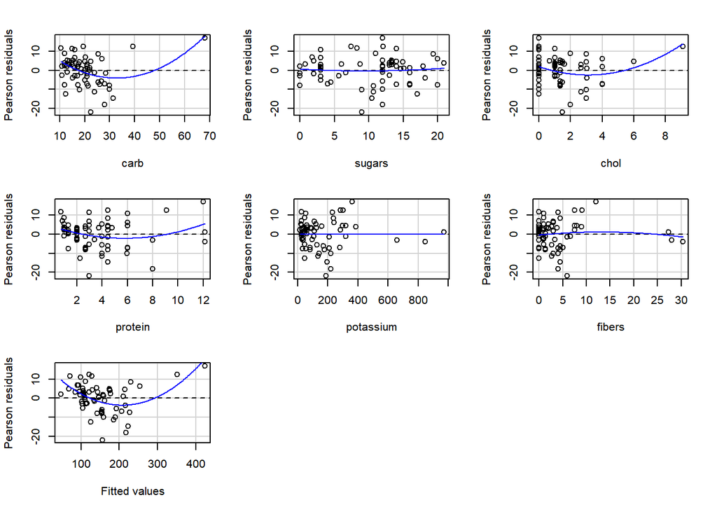

```
##            Test stat Pr(>|Test stat|)
## carb          4.8357        1.044e-05 ***
## sugars        0.3524         0.725815
## chol          2.9742         0.004301 **
## protein       2.2077         0.031303 *
## potassium    -0.0037         0.997100
## fibers       -0.6377         0.526253
## Tukey test    6.7764        1.232e-11 ***
## ---
## Signif. codes:  0 '***' 0.001 '**' 0.01 '*' 0.05 '.' 0.1 ' ' 1
```

```r
residualPlots(step.model)
```

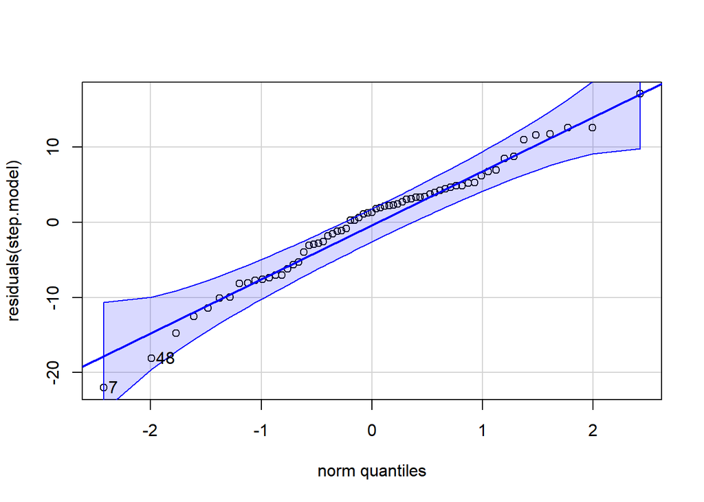

```
## [1]  7 48
```

```r
qqPlot(residuals(step.model))
```

We can see that:

- The qqplot shows just a very little departure from normality on the center, but except for that it’s good.
- Sugars, potassium and fibers plots seem to be all god, as confirmed by their test statistics.
- Carb shows some evident patterns, which is confirmed by a strong test statistic.
- Chol shows a pattern, not as much bad as the one of carb, and protein a very light pattern, and they are both confirmed by their related test statistics.

We can also check the effect plots to check the relation between the predictors and the response, and confirm what we have seen in the summary:

```r
library(effects)
```

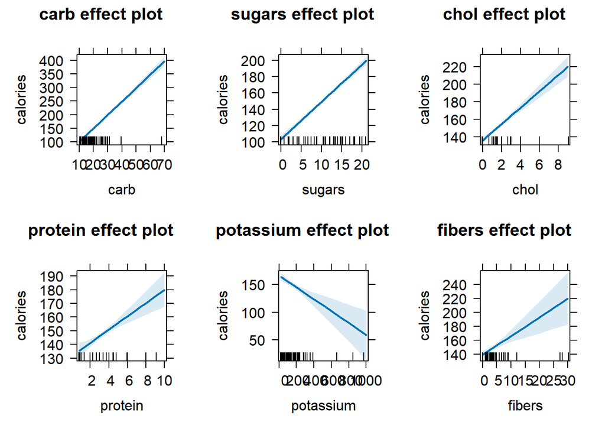

```r
plot(allEffects(step.model))
```

Every effect plot confirms what we have previously said about the predictors in the summary, in fact all the predictor’s changes are very influent towards the response, even if the contribution to the change of the response becomes less clear for potassium and fibers as long as they rise, and for protein happens the same, even if in a very ligher way.

We check for the presence of possible *influential points*:

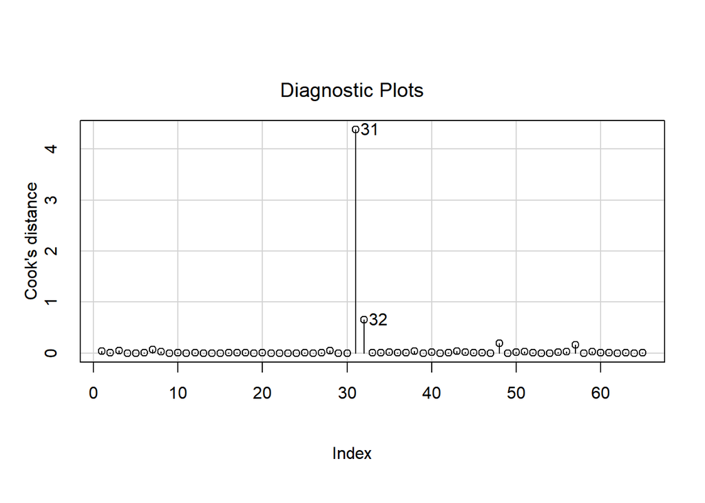

```r
## If an observation is beyond the 0.5 threshold, it's an influential point.
influenceIndexPlot(step.model, vars = "Cook")
```

Clearly, the Influence plot shows a very influent point which goes a lot over the 0.5 threshold, the observation 31, and potentially also the 32 (we say potentially because it’s value is concealed by the very high value of 31).

```r
cereal["31", ]
```

```
##    calories protein chol sodium fibers carb sugars potassium vitamins brand
## 31      440      12    0    680     12   68     12       360   medium     C
```

```r
cereal["32", ]
```

```
##    calories  protein     chol   sodium   fibers     carb   sugars potassium
## 32 363.6364 9.090909 9.090909 227.2727 9.090909 39.39394 12.12121  303.0303
##    vitamins brand
## 32   medium     C
```

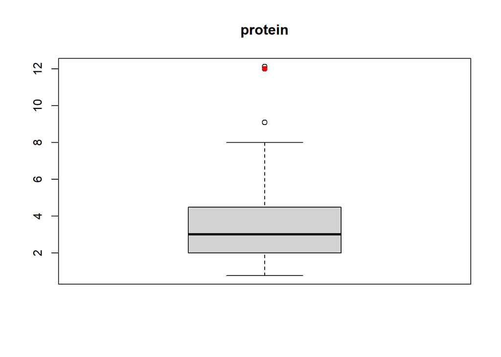

```r
boxplot(cereal$protein, main = "protein")
points(cereal["31", 2], col = "red", pch = 16)
```

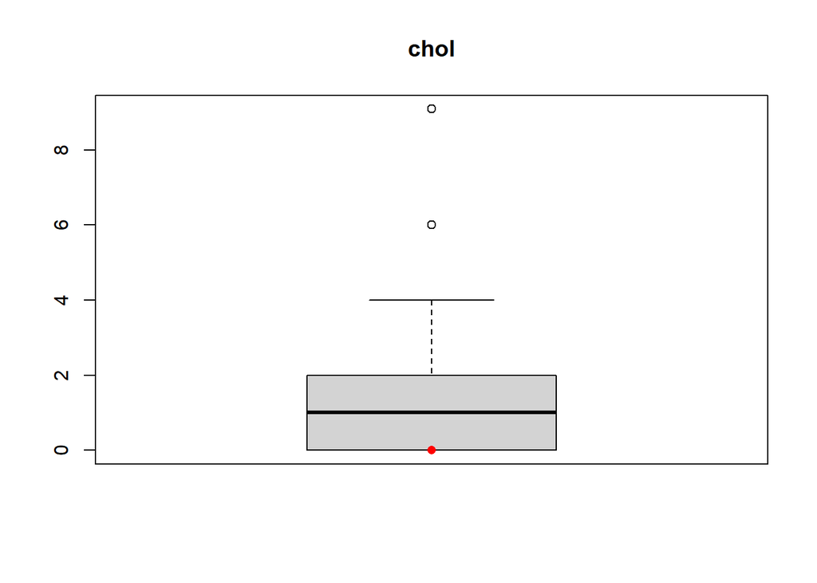

```r
boxplot(cereal$chol, main = "chol")
points(cereal["31", 3], col = "red", pch = 16)
```

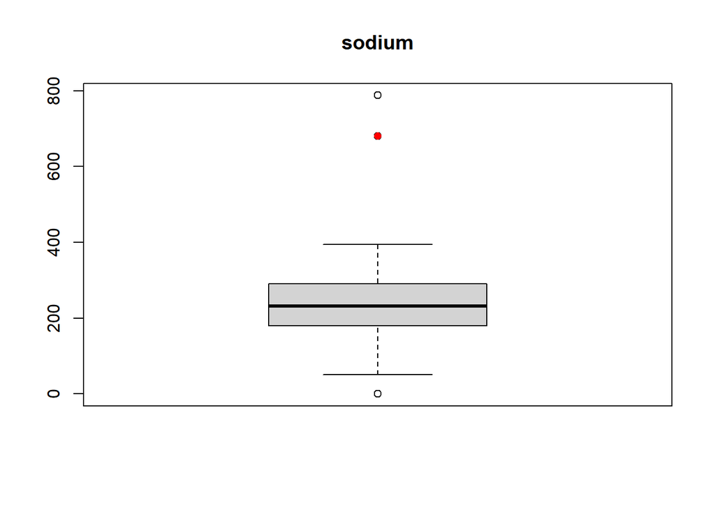

```r
boxplot(cereal$sodium, main = "sodium")
points(cereal["31", 4], col = "red", pch = 16)
```

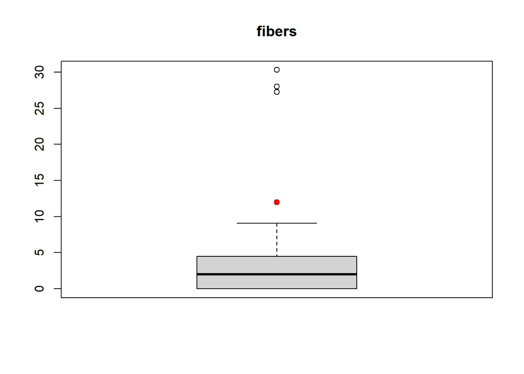

```r
boxplot(cereal$fibers, main = "fibers")
points(cereal["31", 5], col = "red", pch = 16)
```

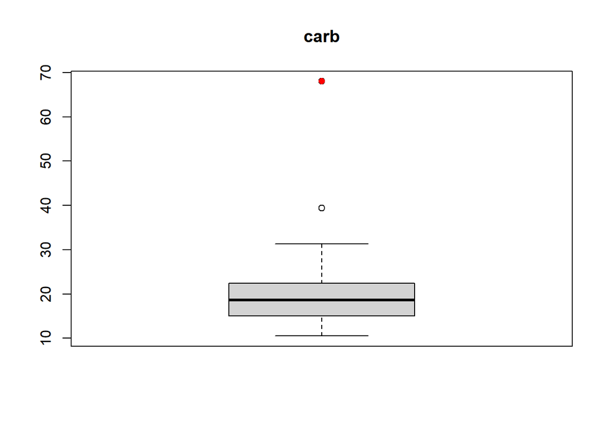

```r
boxplot(cereal$carb, main = "carb")
points(cereal["31", 6], col = "red", pch = 16)
```

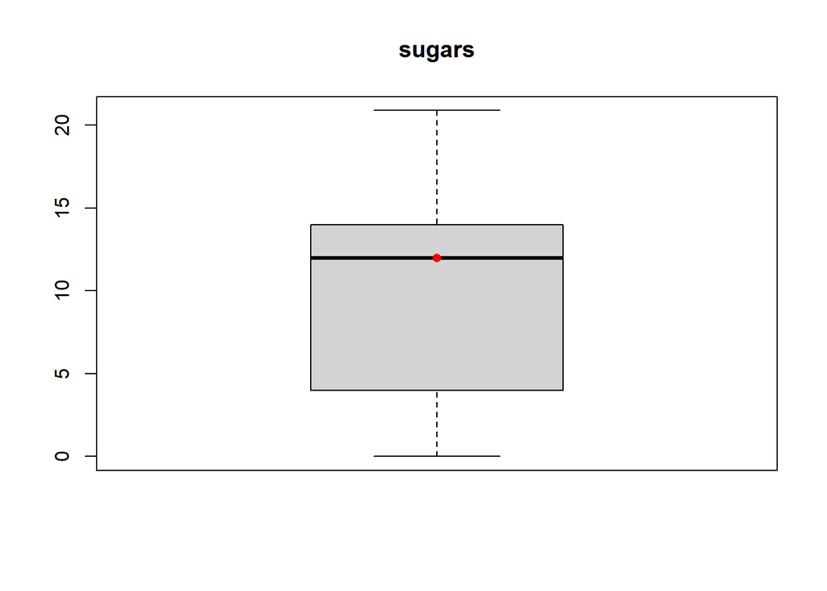

```r
boxplot(cereal$sugars, main = "sugars")
points(cereal["31", 7], col = "red", pch = 16)
```

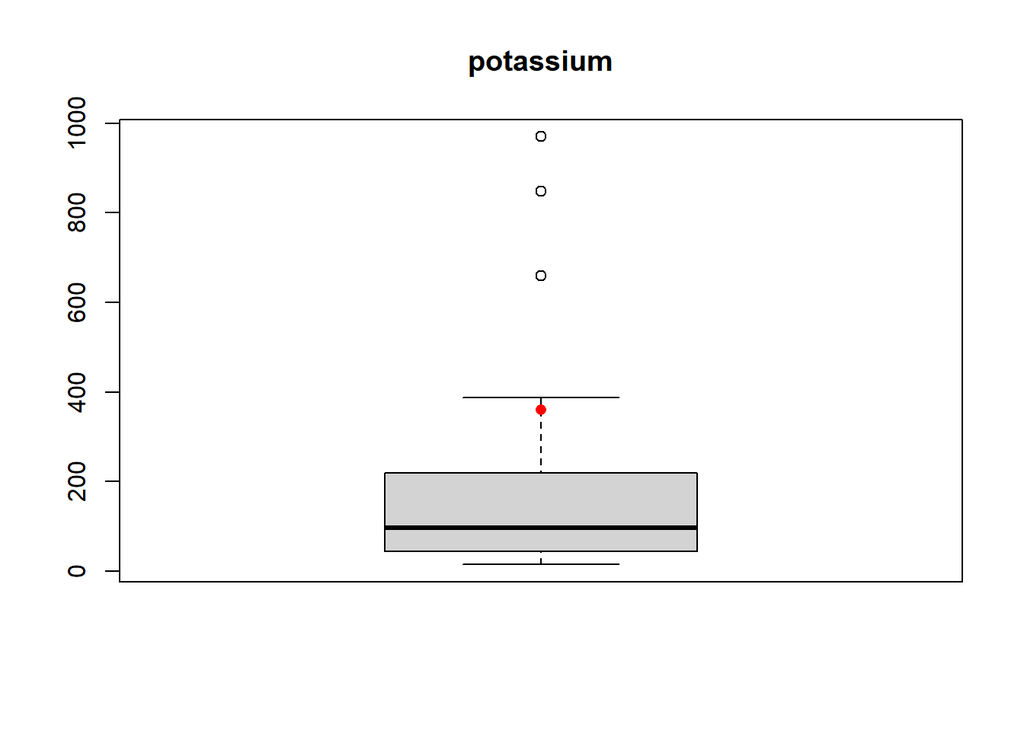

```r
boxplot(cereal$potassium, main = "potassium")
points(cereal["31", 8], col = "red", pch = 16)
```

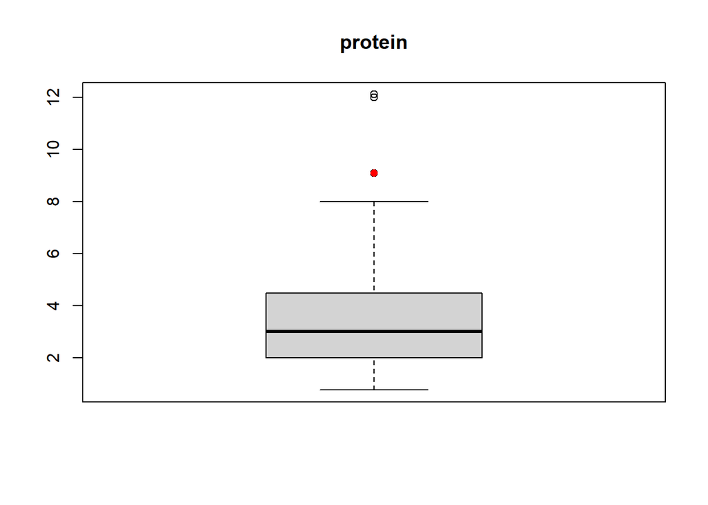

```r
boxplot(cereal$protein, main = "protein")
points(cereal["32", 2], col = "red", pch = 16)
```

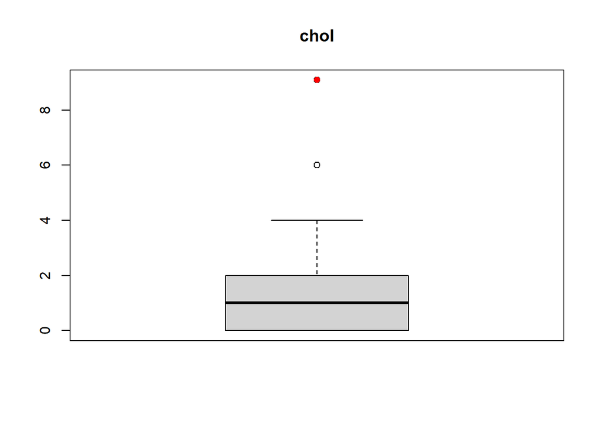

```r
boxplot(cereal$chol, main = "chol")
points(cereal["32", 3], col = "red", pch = 16)
```

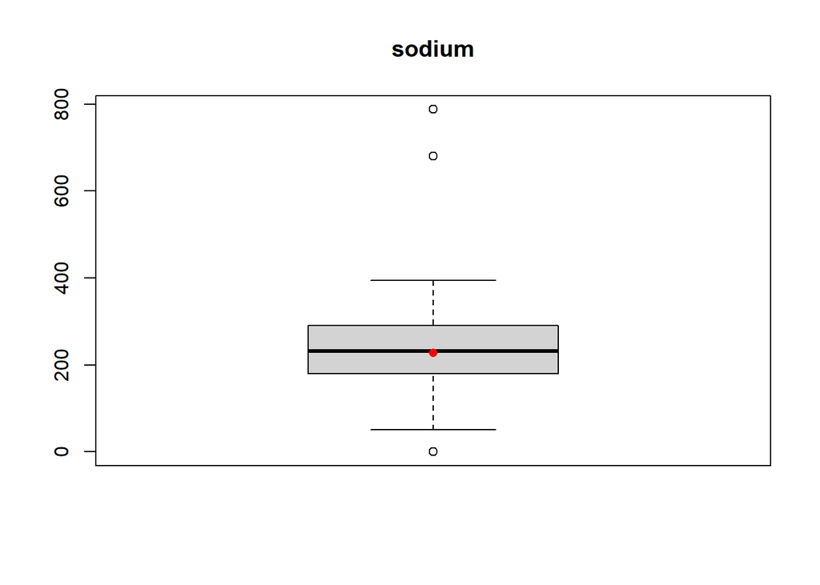

```r
boxplot(cereal$sodium, main = "sodium")
points(cereal["32", 4], col = "red", pch = 16)
```

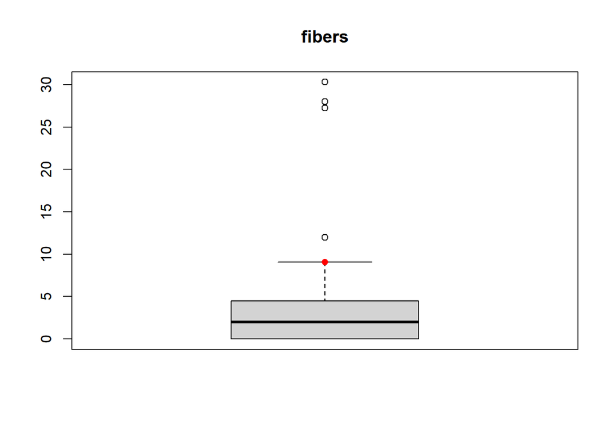

```r
boxplot(cereal$fibers, main = "fibers")
points(cereal["32", 5], col = "red", pch = 16)
```

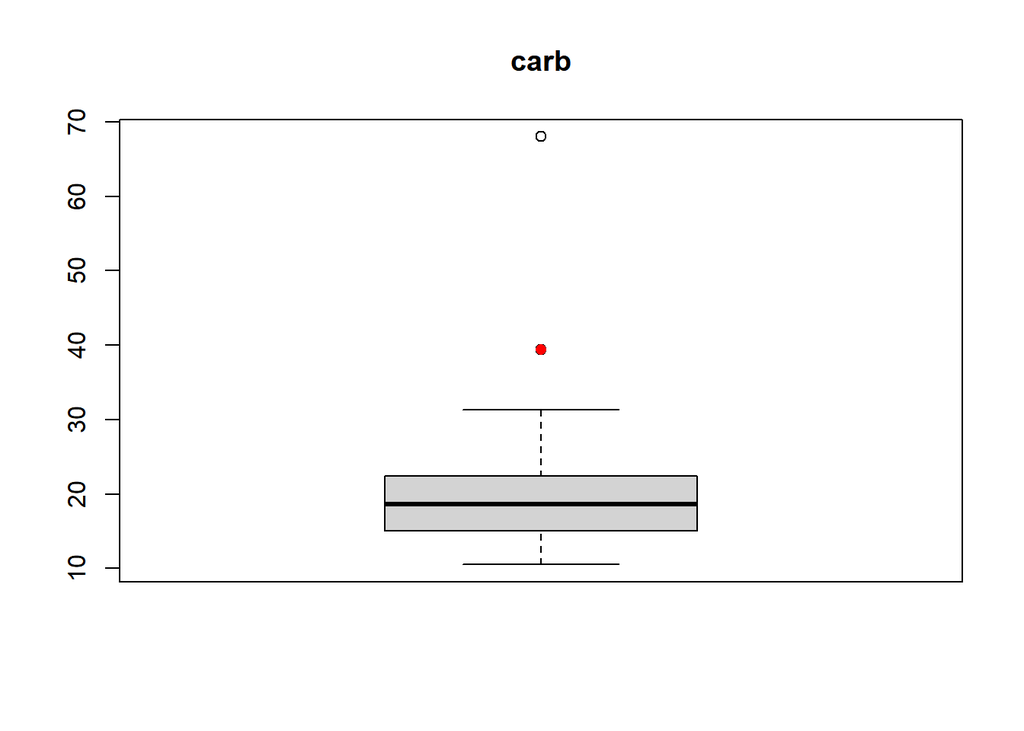

```r
boxplot(cereal$carb, main = "carb")
points(cereal["32", 6], col = "red", pch = 16)
```

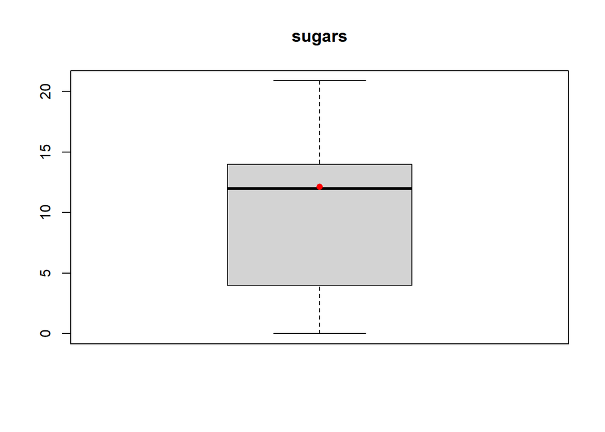

```r
boxplot(cereal$sugars, main = "sugars")
points(cereal["32", 7], col = "red", pch = 16)
```

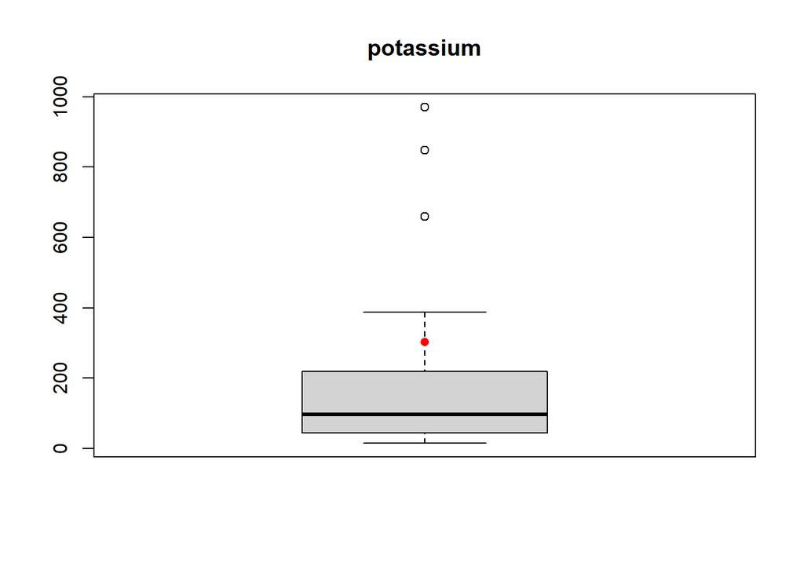

```r
boxplot(cereal$potassium, main = "potassium")
points(cereal["32", 8], col = "red", pch = 16)
```

The observation 31 is a big outlier on more than one predictor, and 32 is also an outlier for cholesterol, so we proceed in their removal and we refit the model:

```r
mod2 <- update(step.model, subset = -which(rownames(cereal) %in% c("31", "32")))
summary(mod2)
```

```
##
## Call:
## lm(formula = calories ~ carb + sugars + chol + protein + potassium +
##     fibers, data = cereal, subset = -which(rownames(cereal) %in%
##     c("31", "32")))
##
## Residuals:
##      Min       1Q   Median       3Q      Max
## -17.9413  -3.8115  -0.2648   4.1138  14.0221
##
## Coefficients:
##             Estimate Std. Error t value Pr(>|t|)
## (Intercept) -2.81192    3.62912  -0.775    0.442
## carb         4.15835    0.17720  23.467  < 2e-16 ***
## sugars       4.19261    0.17715  23.668  < 2e-16 ***
## chol         9.01086    0.75596  11.920  < 2e-16 ***
## protein      3.84631    0.77082   4.990 6.21e-06 ***
## potassium   -0.03049    0.02322  -1.313    0.195
## fibers       0.87042    0.61660   1.412    0.164
## ---
## Signif. codes:  0 '***' 0.001 '**' 0.01 '*' 0.05 '.' 0.1 ' ' 1
##
## Residual standard error: 6.105 on 56 degrees of freedom
## Multiple R-squared:  0.9818, Adjusted R-squared:  0.9799
## F-statistic: 504.6 on 6 and 56 DF,  p-value: < 2.2e-16
```

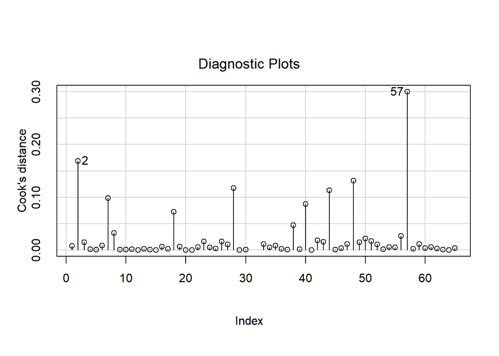

```r
influenceIndexPlot(mod2, vars = "Cook")
```

As we can see in the summary, the $R^2$ and the adjusted $R^2$ have decreased a little, and now only carb, sugars, chol and protein are strongly significant, whereas all the other variables are not significant. (the significant ones are also postively related to the response). Moreover, the influenceindexplot does not suggest any other influential point.

We check the residuals and the normal probability plot:

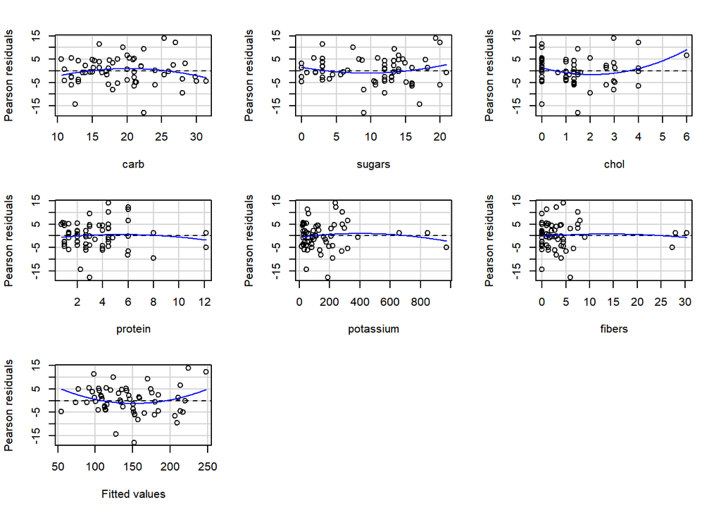

```
##            Test stat Pr(>|Test stat|)
## carb         -1.2814          0.20544
## sugars        1.2314          0.22341
## chol          2.2619          0.02768 *
## protein      -0.7861          0.43521
## potassium    -0.8128          0.41985
## fibers       -0.4300          0.66890
## Tukey test    1.9323          0.05333 .
## ---
## Signif. codes:  0 '***' 0.001 '**' 0.01 '*' 0.05 '.' 0.1 ' ' 1
```

```r
residualPlots(mod2)
```

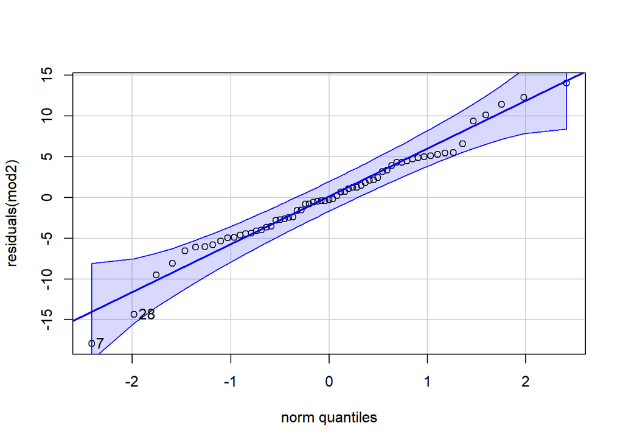

```
## [1]  7 28
```

```r
qqPlot(residuals(mod2))
```

The qqplot has improved, and the residuals have improved a lot, in fact now only chol has a weakly significant test statistics, and all the plots seem very good, except for a very light pattern in carb, chol and in the fitted values.

We can check also for potential multicollinearities:

```r
vif(mod2)
```

```
##      carb    sugars      chol   protein potassium    fibers
##  1.544419  1.827988  1.720714  5.509315 29.189302 23.581219
```

Clearly, there are some strong multicollinearities, as indicated by the values of potassium and fibers, and a multicollinearity indication by protein, so we give a closer look:

```r
with(cereal[-c(31, 32), ], round(cor(cbind(calories,
                                            carb,
                                            sugars,
                                            chol,
                                            protein,
                                            potassium,
                                            fibers)),
                                  2))
```

```
##           calories  carb sugars chol protein potassium fibers
## calories      1.00  0.55   0.66 0.73    0.60      0.52   0.36
## carb          0.55  1.00  -0.13 0.17    0.33      0.18   0.08
## sugars        0.66 -0.13   1.00 0.49    0.18      0.27   0.14
## chol          0.73  0.17   0.49 1.00    0.42      0.35   0.23
## protein       0.60  0.33   0.18 0.42    1.00      0.88   0.83
## potassium     0.52  0.18   0.27 0.35    0.88      1.00   0.96
## fibers        0.36  0.08   0.14 0.23    0.83      0.96   1.00
```

As shown by the vif function, there are some strong correlations between potassium, protein and fibers so we remove potassium and re-fit the model:

```r
mod3 <- update(mod2, . ~ . - potassium, subset = -c(31,32))
summary(mod3)
```

```
##
## Call:
## lm(formula = calories ~ carb + sugars + chol + protein + fibers,
##     data = cereal, subset = -c(31, 32))
##
## Residuals:
##      Min       1Q   Median       3Q      Max
## -17.2095  -3.5073  -0.4758   3.6199  14.1377
##
## Coefficients:
##             Estimate Std. Error t value Pr(>|t|)
## (Intercept)  -0.9437     3.3597  -0.281    0.780
## carb          4.0812     0.1682  24.260  < 2e-16 ***
## sugars        4.0813     0.1565  26.075  < 2e-16 ***
## chol          8.8652     0.7525  11.781  < 2e-16 ***
## protein       3.5325     0.7375   4.790 1.23e-05 ***
## fibers        0.1317     0.2539   0.519    0.606
## ---
## Signif. codes:  0 '***' 0.001 '**' 0.01 '*' 0.05 '.' 0.1 ' ' 1
##
## Residual standard error: 6.143 on 57 degrees of freedom
## Multiple R-squared:  0.9813, Adjusted R-squared:  0.9796
## F-statistic: 597.6 on 5 and 57 DF,  p-value: < 2.2e-16
```

```r
vif(mod3)
```

```
##     carb   sugars     chol  protein   fibers
## 1.374599 1.409215 1.683677 4.979785 3.949756
```

We need to remove also protein, as it’s vif values is still important:

```r
mod4 <- update(mod2, . ~ . - potassium - protein, subset = -c(31,32))
summary(mod4)
```

```
##
## Call:
## lm(formula = calories ~ carb + sugars + chol + fibers, data = cereal,
##     subset = -c(31, 32))
##
## Residuals:
##      Min       1Q   Median       3Q      Max
## -22.7900  -4.3637  -0.9795   3.3189  26.5577
##
## Coefficients:
##             Estimate Std. Error t value Pr(>|t|)
## (Intercept)  -1.0115     3.9444  -0.256    0.799
## carb          4.4402     0.1768  25.111  < 2e-16 ***
## sugars        4.0795     0.1838  22.200  < 2e-16 ***
## chol         10.1781     0.8228  12.370  < 2e-16 ***
## fibers        1.1722     0.1544   7.591 2.97e-10 ***
## ---
## Signif. codes:  0 '***' 0.001 '**' 0.01 '*' 0.05 '.' 0.1 ' ' 1
##
## Residual standard error: 7.212 on 58 degrees of freedom
## Multiple R-squared:  0.9737, Adjusted R-squared:  0.9719
## F-statistic: 537.8 on 4 and 58 DF,  p-value: < 2.2e-16
```

```r
vif(mod4)
```

```
##     carb   sugars     chol   fibers
## 1.101777 1.409207 1.460322 1.059534
```

Finally, there are not any more dangerous vif values, so we can proceed in a final analysis of this fit. The summary tells that all the predictors are strongly significant and positvely related to the response, whereas the intercept is not significant and it’s negatively related to the response. The $R^2$ and adjusted $R^2$ are both $97%$, which is a few less than the beginning model.

Now, we must validate the model assumptions through the residual analysis and the normal probability plot analysis:

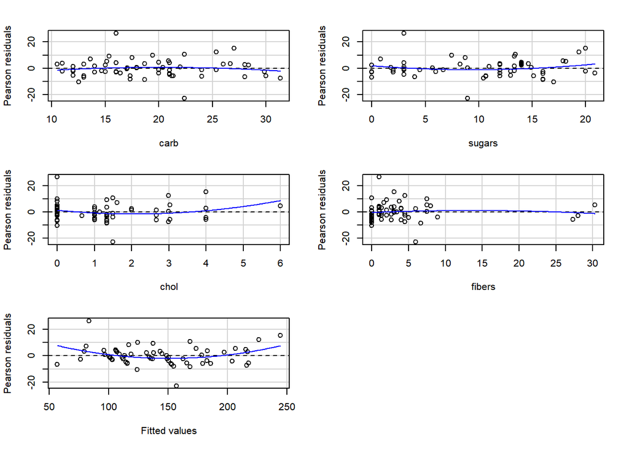

```
##            Test stat Pr(>|Test stat|)
## carb         -0.7788         0.439348
## sugars        1.2463         0.217769
## chol          1.8070         0.076034 .
## fibers       -0.5468         0.586655
## Tukey test    2.7251         0.006428 **
## ---
## Signif. codes:  0 '***' 0.001 '**' 0.01 '*' 0.05 '.' 0.1 ' ' 1
```

```r
library(car)
residualPlots(mod4)
```

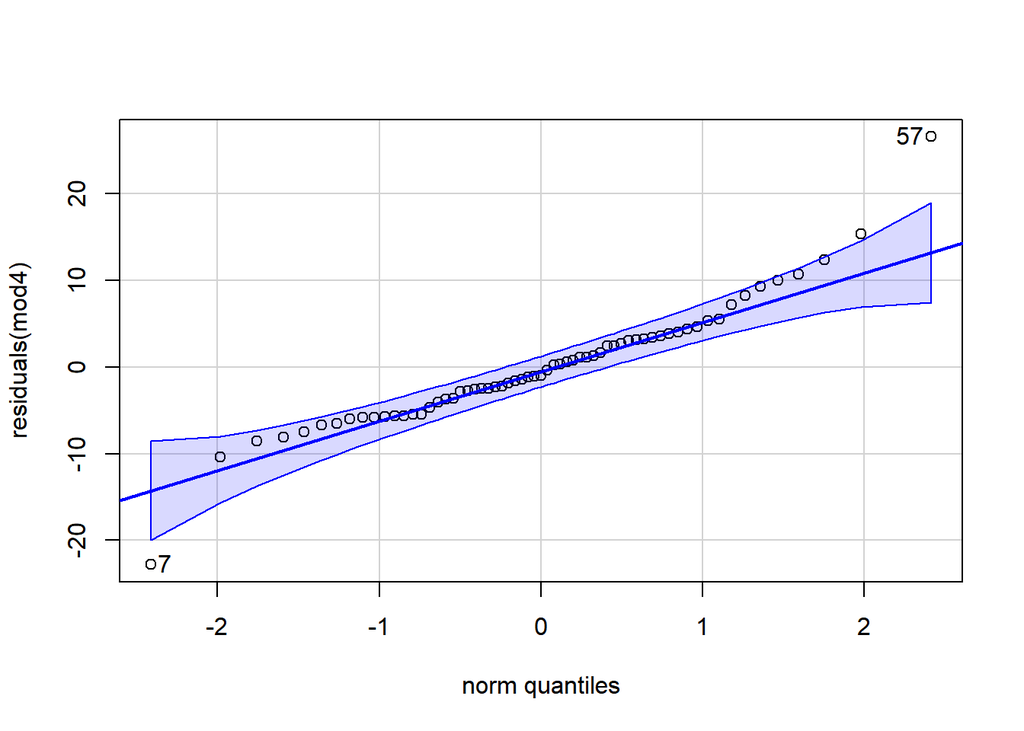

```
## 57  7
## 55  7
```

```r
qqPlot(residuals(mod4))
```

We can also check the effect plots to check the relation between the predictors and the response, and confirm what we have seen in the summary:

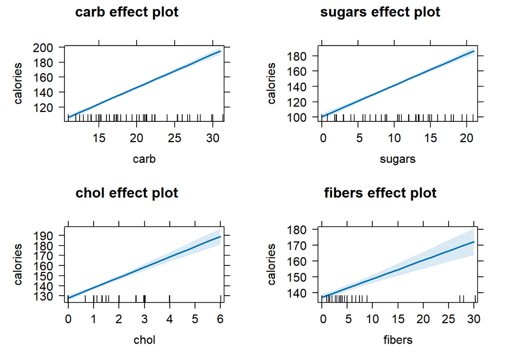

```r
library(effects)
plot(allEffects(mod4))
```

All the predictors are strongly positvely influent on the calories, in fact any increment of them causes a strong increment on the response.

We check if the model produces negative values:

```r
summary(fitted(mod4))
```

```
##    Min. 1st Qu.  Median    Mean 3rd Qu.    Max.
##   56.71  108.91  136.78  141.40  168.46  244.69
```

No, it does not produce negative values, so the model is good, and we can proceed with some computation of prediction and prediction intervals:

```r
head(cereal)
```

```
##   calories   protein     chol   sodium    fibers     carb   sugars potassium
## 1 212.1212 12.121212 3.030303 393.9394 30.303030 15.15152 18.18182 848.48485
## 2 212.1212 12.121212 3.030303 787.8788 27.272727 21.21212 15.15151 969.69697
## 3 100.0000  8.000000 0.000000 280.0000 28.000000 16.00000  0.00000 660.00000
## 4 146.6667  2.666667 2.666667 240.0000  2.000000 14.00000 13.33333  93.33333
## 5 110.0000  2.000000 0.000000 125.0000  1.000000 11.00000 14.00000  30.00000
## 6 173.3333  4.000000 2.666667 280.0000  2.666667 24.00000 10.66667 133.33333
##   vitamins brand
## 1   medium     C
## 2   medium     B
## 3   medium     B
## 4   medium     A
## 5   medium     B
## 6   medium     A
```

```r
pr <- predict(mod4,
              newdata = data.frame(carb = 11,
                                   sugars = 14,
                                   chol = 0.,
                                   fibers = 1),
              se.fit = TRUE)
ci <- pr$fit + c(-1, 1) * qnorm(0.975) * pr$se
ci
```

```
## [1] 102.1930 110.0392
```

```r
pr$fit
```

```
##        1
## 106.1161
```

```r
pr <- predict(mod4,
              newdata = data.frame(carb = 15,
                                   sugars = 10,
                                   chol = 2.,
                                   fibers = 20),
              se.fit = TRUE)
ci <- pr$fit + c(-1, 1) * qnorm(0.975) * pr$se
ci
```

```
## [1] 144.6775 155.6977
```

```r
pr$fit
```

```
##        1
## 150.1876
```

```r
pr <- predict(mod4,
              newdata = data.frame(carb = 40,
                                   sugars = 60,
                                   chol = 6.,
                                   fibers = 33),
              se.fit = TRUE)
ci <- pr$fit + c(-1, 1) * qnorm(0.975) * pr$se
ci
```

```
## [1] 501.8110 540.4287
```

```r
pr$fit
```

```
##        1
## 521.1198
```

As seen in the previous plots, all the chosen predictors are strongly significant, so by increasing any of them the increase of calories is very high.